# Session 8.2 Trees and Random Forests: Classifying iPlayer users

Dr Kanishka Bhattacharya

2021-11-17

# 1 Learning Objectives for Session 8

1. K nearest neighbors (K-NN)
   1. Basics of the algorithm
   2. When does it work?
   3. Tuning the parameters
2. Comparing different supervised algorithms
3. Introduction to ensemble methods: What is the idea behind ensemble methods?
4. Classification and regression trees
   1. Basics of the algorithm – splitting and stopping rules
   2. Visualizing results
   3. Feature importance

# 2 Introduction

In this session I demonstrate the use of trees to predict whether an iPlayer user in january will use the player in February as well. This document is organized as follows.

**Table of Contents**

- Section 1: Learning Objectives for Session 8
- Section 2: Introduction
- Section 3: Fitting basic tree models
- Section 4: Hyperparameter tuning
- Section 5: Variability of trees

First let’s load packages we will need.

```r
options("huxtable.knit_print_df" = FALSE)
if(!is.element("tidyverse", installed.packages()[,1]))
{  install.packages("tidyverse")}

if(!is.element("Hmisc", installed.packages()[,1]))
{  install.packages("Hmisc")} #package for data summary using `describe`

if(!is.element("ggplot2", installed.packages()[,1]))
{  install.packages("ggplot2")} #package for plots
if(!is.element("ggthemes", installed.packages()[,1]))
{  install.packages("ggthemes")} #package to make fancier ggplots
if(!is.element("caret", installed.packages()[,1]))
{  install.packages("caret",dependencies=T)} #package to train machine learning algorithms
if(!is.element("Metrics", installed.packages()[,1]))
{ install.packages("Metrics")}  #package to check the performance of machine learning algorithms

if(!is.element("rpart", installed.packages()[,1]))
{  install.packages("rpart")} #package to fit trees

if(!is.element("rpart.plot", installed.packages()[,1]))
{  install.packages("rpart.plot")} #package to visualize trees

library(tidyverse)
library(lubridate)
library(cluster)
library(rpart)
library(rpart.plot)
library(caret)
library(Metrics)
library(pROC)
```

## 2.1 Reading in BBC Data

Let’s read the user based data. This is the user data we generated in the last rmarkdown document when we implement K-NN. Then I generate training and test data sets, as usual.

```r
userBasedData <- read.csv(file="UserBasedData_S8.csv",header=TRUE)
head(userBasedData)
```

```
##   noShows  total_Time   weekday   weekend Afternoon        Day   Evening
## 1       2  16.6792000 1.0000000 0.0000000         0 0.00000000 1.0000000
## 2       2   0.3103333 1.0000000 0.0000000         0 1.00000000 0.0000000
## 3       2   1.8663000 1.0000000 0.0000000         0 1.00000000 0.0000000
## 4       1   1.0636167 0.0000000 1.0000000         0 0.00000000 1.0000000
## 5      31 534.3555667 0.8709677 0.1290323         0 0.09677419 0.8064516
## 6       1   1.3133667 1.0000000 0.0000000         0 0.00000000 1.0000000
##        Night Children   Comedy    Drama Entertainment  Factual Learning
## 1 0.00000000        0 0.000000  0.00000      0.000000  0.00000        0
## 2 0.00000000        0 0.000000  0.00000      0.000000  0.00000        0
## 3 0.00000000        0 0.000000  0.00000      0.000000  0.00000        0
## 4 0.00000000        0 0.000000  0.00000    100.000000  0.00000        0
## 5 0.09677419        0 6.451613 32.25806      6.451613 41.93548        0
## 6 0.00000000        0 0.000000  0.00000    100.000000  0.00000        0
##      Music       News NoGenre RelEthics    Sport Weather per_al_Watched
## 1 0.000000 100.000000       0         0 0.000000       0       50.00000
## 2 0.000000 100.000000       0         0 0.000000       0        0.00000
## 3 0.000000 100.000000       0         0 0.000000       0        0.00000
## 4 0.000000   0.000000       0         0 0.000000       0        0.00000
## 5 6.451613   3.225806       0         0 3.225806       0       22.58065
## 6 0.000000   0.000000       0         0 0.000000       0      100.00000
##   watched_in_Feb
## 1             No
## 2            Yes
## 3             No
## 4            Yes
## 5             No
## 6             No
```

```r
combined_trees<-userBasedData

####Let's first generate a training and test data set
library(rsample)
set.seed(100)
train_test_split <- initial_split(combined_trees, prop = 0.75) #training set contains 75% of the data
# Create the training dataset
combined_train <- training(train_test_split)
combined_test <- testing(train_test_split)
```

# 3 Fitting tree models

I first demonstrate how to fit trees with pre-pruning. Specifically I force the tree algorithm to stop when the number of observations in a leaf node falls below a limit. Then I demonstrate how to use additional arguments to modify the tree model.

## 3.1 Fitting a basic tree

I will use the `rpart` function from the `rpart` package. I will use the `rpart.plot` function to plot the results.

`rpart` function provides many options to stop the growth of a tree (see below). Let’s fit a tree using various options.

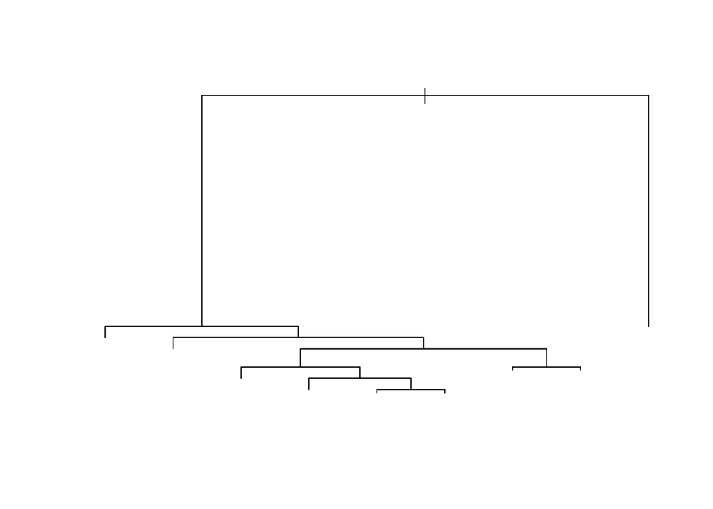

```r
# Below 'cp' is a complexity metric. We will take a more detailed look below
# 'maxdepth' is the maximum depth of the tree is allowed to grow
# 'minbucket' is the minimum number of observations allowed in a leaf
# 'minsplit' is the minimum number of observations allowed for a leaf to be considered for a split
# Change minbucket =50 once you run this version
BBC_treeModel_oos <- rpart(formula=watched_in_Feb  ~ .,
                           data = combined_train,method = "class",
                           control = rpart.control(cp = 0, maxdepth = 20,minbucket=200,minsplit=2))


plot(BBC_treeModel_oos)
```

```r
#Summarize the results
summary(BBC_treeModel_oos)
```

```
## Call:
## rpart(formula = watched_in_Feb ~ ., data = combined_train, method = "class",
##     control = rpart.control(cp = 0, maxdepth = 20, minbucket = 200,
##         minsplit = 2))
##   n= 7013
##
##            CP nsplit rel error    xerror       xstd
## 1 0.312639287      0 1.0000000 1.0000000 0.01325812
## 2 0.010612332      1 0.6873607 0.7042343 0.01238907
## 3 0.004457179      4 0.6555237 0.6727157 0.01223286
## 4 0.003289823      5 0.6510665 0.6666667 0.01220132
## 5 0.000000000      8 0.6411971 0.6701687 0.01221964
##
## Variable importance
##        noShows     total_Time         Comedy  Entertainment          Night
##             35             24             10              9              9
##      Afternoon          Drama per_al_Watched        Evening            Day
##              9              1              1              1              1
##
## Node number 1: 7013 observations,    complexity param=0.3126393
##   predicted class=Yes  expected loss=0.4478825  P(node) =1
##     class counts:  3141  3872
##    probabilities: 0.448 0.552
##   left son=2 (4262 obs) right son=3 (2751 obs)
##   Primary splits:
##       noShows        < 4.5         to the left,  improve=608.3603, (0 missing)
##       total_Time     < 99.28185    to the left,  improve=547.4214, (0 missing)
##       per_al_Watched < 0.3571429   to the left,  improve=283.1058, (0 missing)
##       Drama          < 0.5376344   to the left,  improve=221.4845, (0 missing)
##       Comedy         < 0.204918    to the left,  improve=212.2233, (0 missing)
##   Surrogate splits:
##       total_Time    < 93.38452    to the left,  agree=0.871, adj=0.671, (0 split)
##       Comedy        < 0.204918    to the left,  agree=0.731, adj=0.316, (0 split)
##       Entertainment < 0.3731343   to the left,  agree=0.722, adj=0.290, (0 split)
##       Night         < 0.00204918  to the left,  agree=0.717, adj=0.280, (0 split)
##       Afternoon     < 0.005747126 to the left,  agree=0.716, adj=0.275, (0 split)
##
## Node number 2: 4262 observations,    complexity param=0.01061233
##   predicted class=No   expected loss=0.3847959  P(node) =0.6077285
##     class counts:  2622  1640
```

[output cut: 136 more lines]

```
##       per_al_Watched < 41.66667    to the right, agree=0.618, adj=0.173, (0 split)
##       total_Time     < 19.40446    to the left,  agree=0.610, adj=0.155, (0 split)
##       Factual        < 41.66667    to the right, agree=0.585, adj=0.102, (0 split)
##       weekday        < 0.875       to the right, agree=0.584, adj=0.099, (0 split)
##       weekend        < 0.125       to the left,  agree=0.584, adj=0.099, (0 split)
##
## Node number 182: 284 observations
##   predicted class=No   expected loss=0.471831  P(node) =0.04049622
##     class counts:   150   134
##    probabilities: 0.528 0.472
##
## Node number 183: 331 observations
##   predicted class=Yes  expected loss=0.4531722  P(node) =0.04719806
##     class counts:   150   181
##    probabilities: 0.453 0.547
```

```r
#We can also see how important each variable. There is no statistical test however.
varImp(BBC_treeModel_oos)
```

```
##                   Overall
## Comedy         212.223312
## Day              6.627318
## Drama          256.676307
## Evening          2.431584
## Factual          2.474984
## noShows        711.705280
## per_al_Watched 319.053294
## Sport           15.862296
## total_Time     654.385810
## weekday         27.481263
## weekend         27.481263
## Afternoon        0.000000
## Night            0.000000
## Children         0.000000
## Entertainment    0.000000
## Learning         0.000000
## Music            0.000000
## News             0.000000
## NoGenre          0.000000
## RelEthics        0.000000
## Weather          0.000000
```

## 3.2 Visualizing trees

`rpart.plot` function has many different options for plotting; see http://www.milbo.org/rpart-plot/prp.pdf

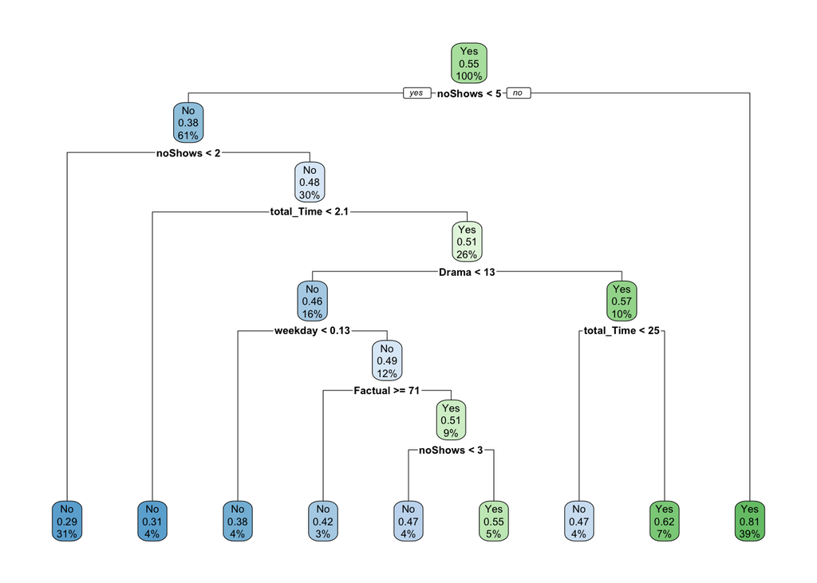

```r
# Let's plot the resulting tree in two different ways. Compare the results to see the differences.

rpart.plot(BBC_treeModel_oos)
```

> Exercise: Use different options to visualize the resulting tree. For example run the following code. rpart.plot(bbc_tree_Fit, type = 3, box.palette = c(“red”, “green”), fallen.leaves = TRUE)

## 3.3 Fitting tree models with more options

`rpart` function provides many options to stop the growth of a tree (see below). Let’s fit a tree using various options.

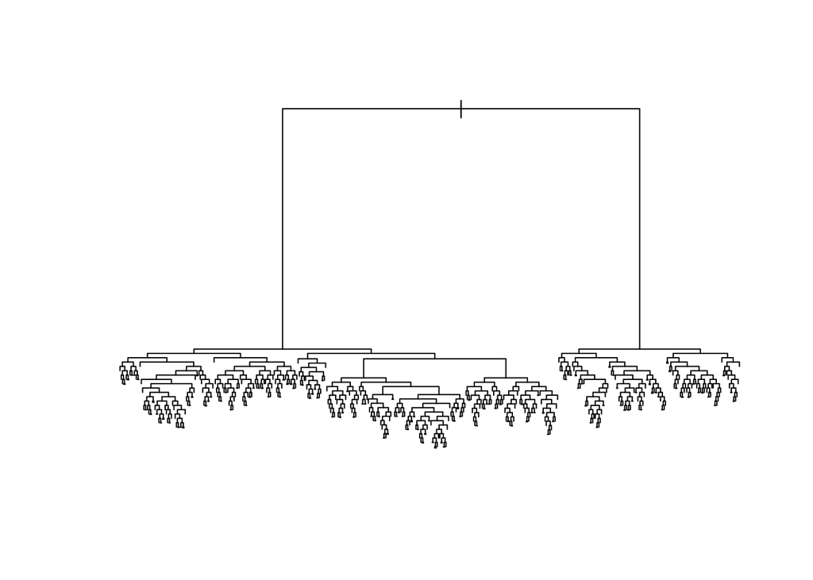

```r
# Below 'cp' is a complexity metric. We will take a more detailed look below
# 'maxdepth' is the maximum depth of the tree is allowed to grow
# 'minbucket' is the minimum number of observations allowed in a leaf
# 'minsplit' is the minimum number of observations allowed for a leaf to be considered for a split
# Change minbucket =50 once you run this version
BBC_treeModel_oos <- rpart(formula=watched_in_Feb  ~ .,
                           data = combined_train,method = "class",
                           control = rpart.control(cp = 0, maxdepth = 20,minbucket=5,minsplit=2))

#Be careful with plotting large trees. it may take a long time
#If you think there are a lot of leafs just use 'plot' instead of 'rpart.plot'
plot(BBC_treeModel_oos)
```

Let’s see how our tree performs in predicting usage in February. Let’s look at the confusion matrix first. How do the results look? Compare it with the results of logistic regression.

```r
class_largetree <-predict(BBC_treeModel_oos, cutoff = .5 , type = "class")
confusionMatrix(data = class_largetree, reference = as.factor(combined_train$watched_in_Feb))
```

```
## Confusion Matrix and Statistics
##
##           Reference
## Prediction   No  Yes
##        No  2619  660
##        Yes  522 3212
##
##                Accuracy : 0.8315
##                  95% CI : (0.8225, 0.8401)
##     No Information Rate : 0.5521
##     P-Value [Acc > NIR] : < 2.2e-16
##
##                   Kappa : 0.6606
##
##  Mcnemar's Test P-Value : 6.752e-05
##
##             Sensitivity : 0.8338
##             Specificity : 0.8295
##          Pos Pred Value : 0.7987
##          Neg Pred Value : 0.8602
##              Prevalence : 0.4479
##          Detection Rate : 0.3734
##    Detection Prevalence : 0.4676
##       Balanced Accuracy : 0.8317
##
##        'Positive' Class : No
##
```

Let’s now plot the ROC curve. How do the results look?

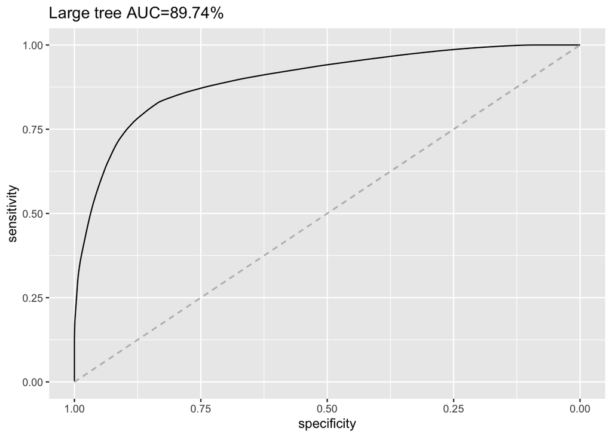

```r
#Predict probability of watching in february
watched_prob <- predict(BBC_treeModel_oos, type = "prob")[,2]

#Draw ROC chart
ROC <- roc(combined_train$watched_in_Feb, watched_prob)

# Calculate AUC
AUC_train<-round(ROC$auc*100, digits=2)
AUC_train_text<-paste("Large tree AUC=",round(ROC$auc*100, digits=2),"%",sep = "")

#Use ggroc to Draw ROC chart
g <- ggroc(ROC)
g +  ggtitle(AUC_train_text) +
  geom_segment(aes(x = 1, xend = 0, y = 0, yend = 1), color="grey", linetype="dashed")
```

This, however, is a little misleading because we use the training data to test the performance of the model. Let’s use the testing data next. What do you think about the results?

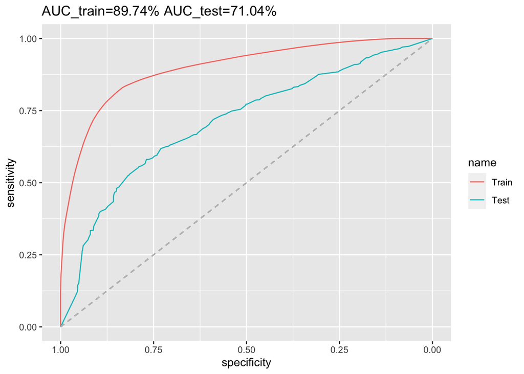

```r
## I use the same code I used in the above chunk by changing the data set from 'combined_train' to 'combined_test'
watched_M2_prob <- predict(BBC_treeModel_oos,combined_test, type = "prob")[,2]
ROC_test <- roc(combined_test$watched_in_Feb, watched_M2_prob)
AUC_test=round(ROC_test$auc*100, digits=2);

# Plot the ROC curve
g2 <- ggroc(list("Train"=ROC, "Test"=ROC_test))
g2+ggtitle(paste("AUC_train=",AUC_train,"%"," AUC_test=",AUC_test,"%",sep = ""))+
  geom_segment(aes(x = 1, xend = 0, y = 0, yend = 1), color="grey", linetype="dashed")
```

> Exercise: What can you conclude from this ROC?

> Exercise: Fit a new tree model by setting `minbucket=50`. How do the results change? Which model performed better? Why?

# 4 Hyperparameter tuning using ‘caret’ package

I use the `train` function below to tune parameter `cp`. Recall that cp controls the complexity of the tree by adding a cost term to the objective function that takes into account the size of the trees.

Let’s start with a simple model.

```r
set.seed(100)
model2 <- train(
  watched_in_Feb  ~ ., data = combined_train,
  method = "rpart",
  trControl = trainControl("cv", number = 10),
  tuneLength = 10
  )
# Plot model accuracy vs different values of
# cp (complexity parameter): train function chooses the value if we do not specify what cp values it shoudl consider.

#we can display the performance of the tree algorithm as a function of cp
print(model2)
```

```
## CART
##
## 7013 samples
##   21 predictor
##    2 classes: 'No', 'Yes'
##
## No pre-processing
## Resampling: Cross-Validated (10 fold)
## Summary of sample sizes: 6312, 6311, 6312, 6312, 6312, 6312, ...
## Resampling results across tuning parameters:
##
##   cp           Accuracy   Kappa
##   0.001432665  0.6948529  0.3877205
##   0.001485726  0.6948529  0.3877205
##   0.001591850  0.6967072  0.3919557
##   0.001910220  0.6958509  0.3905804
##   0.002546960  0.6964215  0.3928666
##   0.002865330  0.6985599  0.3976338
##   0.003820439  0.7004139  0.4016074
##   0.005093919  0.7018401  0.4052614
##   0.010612332  0.6961339  0.3917346
##   0.312639287  0.6048813  0.1526817
##
## Accuracy was used to select the optimal model using the largest value.
## The final value used for the model was cp = 0.005093919.
```

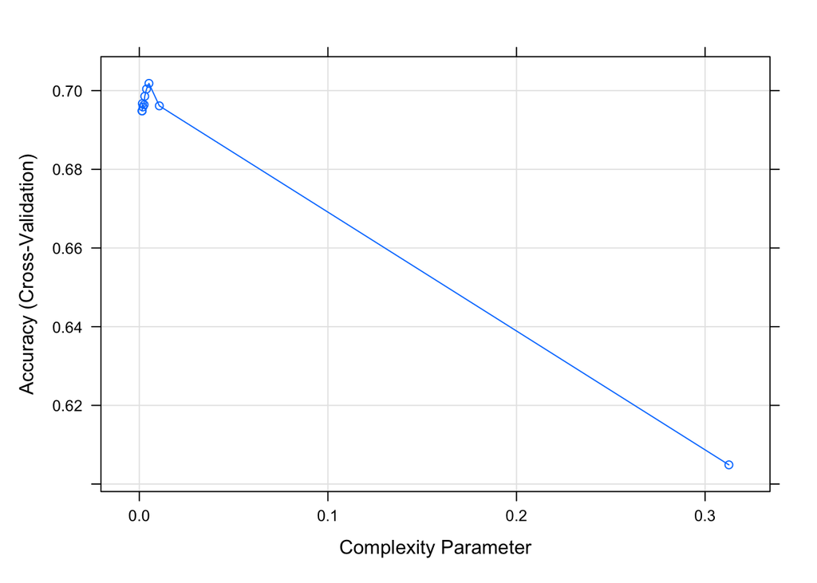

```r
#or plot the results
plot(model2)
```

Let’s do something more sophisticated.

```r
# I am using the standard set-up for the train function for classification.
# The main difference from previous examples is that now we are tuning 'cp'

modelLookup("rpart")
```

```
##   model parameter                label forReg forClass probModel
## 1 rpart        cp Complexity Parameter   TRUE     TRUE      TRUE
```

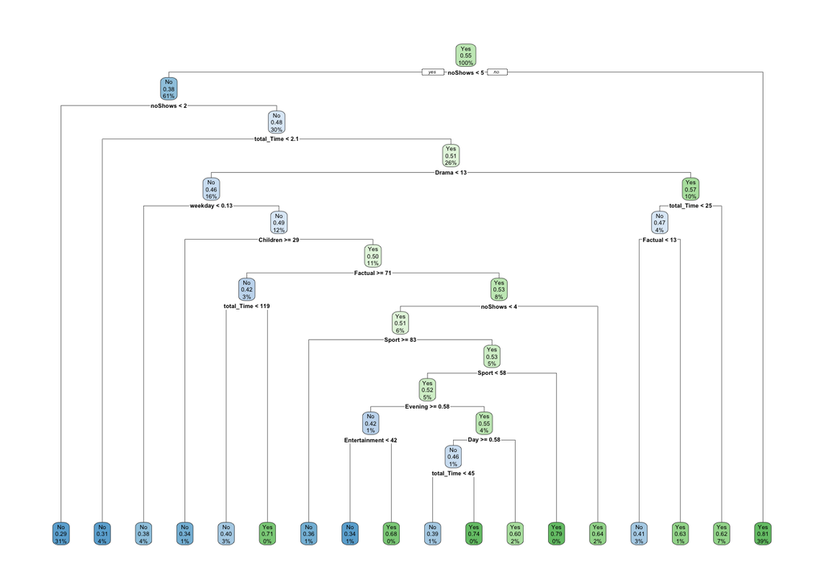

```r
# Let's set reasonable values for 'cp'
trctrl <- trainControl(method = "cv",
                       number = 5,
                       classProbs=TRUE,
                       summaryFunction=twoClassSummary)

#I choose cp values that seems to result in low error based on plot above
Grid <- expand.grid(cp = seq( 0.0000, 0.0020,0.0001))

dtree_fit <- train(watched_in_Feb  ~ .,
                   data = combined_train,
                   method = "rpart",
                   metric="ROC",
                   trControl=trctrl,
                   tuneGrid=Grid)
# Plot the best tree model found
rpart.plot(dtree_fit$finalModel)
```

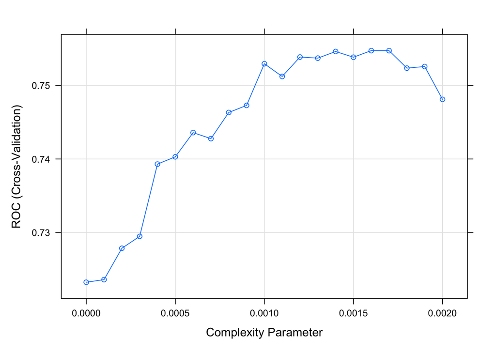

```r
# Print the search results of 'train' function
 plot(dtree_fit)
```

```r
print(dtree_fit)
```

```
## CART
##
## 7013 samples
##   21 predictor
##    2 classes: 'No', 'Yes'
##
## No pre-processing
## Resampling: Cross-Validated (5 fold)
## Summary of sample sizes: 5610, 5610, 5610, 5611, 5611
## Resampling results across tuning parameters:
##
##   cp      ROC        Sens       Spec
##   0.0000  0.7232576  0.6351574  0.6751061
##   0.0001  0.7236157  0.6361128  0.6756232
##   0.0002  0.7278739  0.6475778  0.6753668
##   0.0003  0.7294923  0.6593602  0.6766615
##   0.0004  0.7393079  0.6829155  0.6844038
##   0.0005  0.7402967  0.6886479  0.6838906
##   0.0006  0.7435837  0.6985185  0.6844081
##   0.0007  0.7427657  0.7055239  0.6838960
##   0.0008  0.7463205  0.7045664  0.6895747
##   0.0009  0.7472775  0.7020242  0.6939658
##   0.0010  0.7529404  0.6994719  0.6988704
##   0.0011  0.7512106  0.7020197  0.6970649
##   0.0012  0.7538523  0.7080737  0.6911244
##   0.0013  0.7537004  0.7055259  0.6942212
##   0.0014  0.7546028  0.7058393  0.6973177
##   0.0015  0.7538254  0.7061578  0.6983513
##   0.0016  0.7547192  0.7179362  0.6898251
##   0.0017  0.7547192  0.7179362  0.6898251
##   0.0018  0.7523447  0.7172992  0.6942122
##   0.0019  0.7525623  0.7141145  0.6967962
##   0.0020  0.7480990  0.7239897  0.6911258
##
## ROC was used to select the optimal model using the largest value.
## The final value used for the model was cp = 0.0017.
```

Let’s examine the predictive performance of the best tree in the test data.

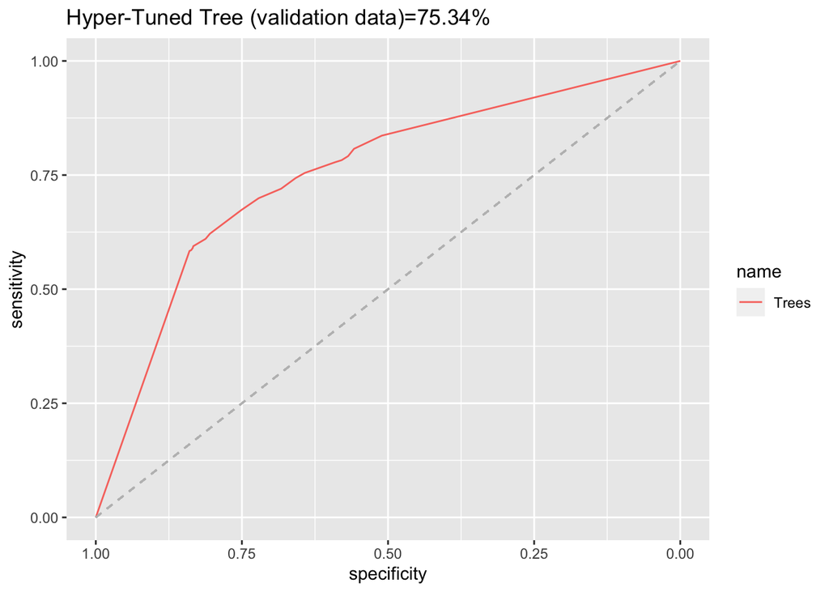

```r
# This is the same code I used above.
library(ggthemes)
watched_prob <- predict(dtree_fit,combined_test, type = "prob")[,2]
ROC_best_tree <- roc(combined_test$watched_in_Feb, watched_prob)
AUC_best_tree<-round(ROC_best_tree$auc*100, digits=2)
# Plot the ROC curve
g2 <- ggroc(list("Trees"=ROC_best_tree))
title<-paste("Hyper-Tuned Tree (validation data)=",AUC_best_tree,"%",sep="")
g2+ggtitle(title) +geom_segment(aes(x = 1, xend = 0, y = 0, yend = 1), color="grey", linetype="dashed")
```